# Staatsoper Hamburg - Stück: Modest P. Mussorgsky | Boris Godunow

Mi 20.09.2023, 19.00 - 21.10 Uhr | Großes Haus

[figure not shown]

# Boris Godunow

**Einführung um 18.20 Uhr**

Als die „Zeit der Wirren“ werden in Russland die Jahre zwischen dem Tod Iwans des Schrecklichen und der Thronbesteigung der Romanows bezeichnet. In diesem Zeitraum drängt Boris Godunow mit unbedingtem Willen an die Macht. Jedoch die Geister der Vergangenheit holen ihn ein, er stirbt wahnsinnig und von allen verlassen und verraten. Das Land versinkt unterdessen immer tiefer in Korruption, Staatsstreichen und Intrigen. Eine neue „Zeit der Wirren“ bricht zu Lebzeiten Modest Mussorgskys an: Die alte Ordnung wankt und kann nicht länger Bestand haben, das spüren alle. In einer Periode politischer Umbrüche und geschüttelt durch dramatische Verwerfungen in seinem Privatleben schafft Mussorgsky ein Werk über die Arroganz der Macht und die Erotik des Verrats, das so widersprüchlich und faszinierend ist wie seine Persönlichkeit.  
Inszenierung: Frank Castorf  
Bühne: Aleksandar Denić  
Kostüme: Adriana Braga Peretzki  
Licht: Rainer Casper  
Video: Andreas Deinert, Severin Renke, Jens Crull, Maryvonne Riedelsheimer  
Dramaturgie: Patric Seibert

Altersempfehlung: Ab 15 Jahren

In russischer Sprache mit deutschen und englischen Übertiteln  
Unterstützt durch die Stiftung zur Förderung der Hamburgischen Staatsoper und die J.J. Ganzer Stiftung

#### Impressionen

[figure not shown]

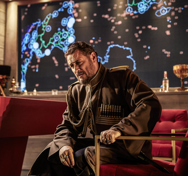

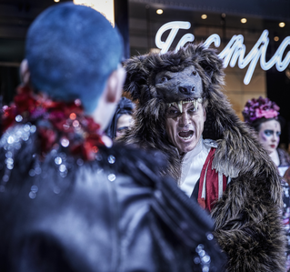

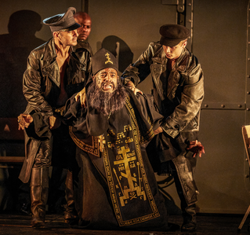

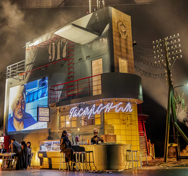

#### Video

[interactive chart not shown]

#### Video

[interactive chart not shown]

Staatsoper Hamburg

Ort: Großes Haus, Dammtorstraße 28, 20354 Hamburg  
Preise: 6,00 EUR bis 109,00 EUR

[figure not shown]

[figure not shown]

[figure not shown]

[figure not shown]

[interactive chart not shown]